# Exam Summary - Group: Data Freak

Fatemeh, Pratik, Sebastian

2025-09-26

## Report

This is the exam summary for group `"Data Freak"`, consisting of 3 people. This project is part of the RMED901 course, and the answers were prepared by our group.

We created the GitHub repository `"data_freak_exam_project"` for this exam. This log is made to show that each of us worked on a part of the final report and to be used for the final evaluation.

## Folder structure

The main folder contains a README.md with the complete folder structure and containing files.  
The repository contains the following folders:

```
scripts:  - one folder for every task 1 - 6,
          - scripts from each group member for each task, with the corresponding part of the task,
          - one merged script per task with all important code used for pipelines and/or plots
          - a descriptive .md-file for every task
          - the exam summary as .Rmd- and .html-file in task 6

data:     - including all 2 used raw data sets, a codebook and 2 created tidy and morphed data sets for use in scripts

results:  - two created tidied and morphed data sets as result for task 2 and 3
          - corresponding codebooks for each data set
          - .html output of the end report for exam

questions:- exam questions
```

## Raw data

We received a data set split into two parts: `exam_data.txt` and `exam_data_join.txt`, as well as the corresponding codebook (`codebook_exam_data.html`).

`exam_data.txt`:

```
## # A tibble: 1 × 15
##   subject    `gender-age` clinic_name result demo_group drive_thru_ind ct_result
##   <chr>      <chr>        <chr>       <chr>  <chr>               <dbl>     <dbl>
## 1 6812 bess… female-2     clinical l… negat… patient                 1        45
## # ℹ 8 more variables: orderset <dbl>, payor_group <chr>, patient_class <chr>,
## #   `pan day` <dbl>, `1_test_id` <chr>, row <dbl>, `time measurement` <chr>,
## #   .value <dbl>
```

`exam_data_join.txt`:

```
## # A tibble: 1 × 2
##      id antibody
##   <dbl>    <dbl>
## 1   172     159.
```

## Tasks

### Task 1 - Create an RStudio project and GitHub repository.

We created an RStudio project and GitHub repository with the name `data_freak_exam_project` and is made in RStudio, with GitHub for collaboration.  
URL: `https://github.com/FatemehH-1999/data_freak_exam_project.git`

Folder structure was described above.

### Task 2 - Read and tidy the dataset.

#### Loading libraries, read and glimpse at data set

To read and tidy the given raw data `exam_data.txt` we first loaded the libraries `here` and `tidyverse`. The data set `exam_data.txt` was imported into R using the `read_delim` function with the delimiter `"\t"`. We glimpsed at the data set, which contains *34048* observations of *15* variables.

#### Checking for duplicates

Next, we checked for duplicates and found *12344* unique entries. This points to duplicates being present.

#### Checking for columns with unfavorable name structure

We checked for difficult for R to interpret column names. We found 5 that need columns to be changed:  
`gender-age`, `pan day`, `1_test_id`, `time measurement` and `.value` –>  
`gender_age`, `pan_day`, `test_id`, `time_measurement` and `value`.

#### Looking for columns to separate

Two columns need to be split up to acquire a tidy data set:  
`subject` -> separated into `ID`, `First_Name`, `Last_Name` and  
`gender_age` -> separated into `gender` and `age`

#### Checking variable types

The two columns `ID` and `age` have to be changed from type `character` to type `numeric`.

#### Writing file to save tidied data set

Lastly, we saved the new data set as `exam_data_tidy_2025-09-08.txt` with the function `write_delim` and the delimiter `" "`. A glimps at the data set, revealed *34048* observations of now *18* variables.

`exam_data_tidy_2025-09-08.txt`:

[output not shown]

### Task 3 - Tidy, adjust, and explore.

#### Loading libraries, read and glimpse at data set

To read and further tidy our data set `exam_data_tidy_2025-09-08.txt` we first loaded the libraries `here` and `tidyverse`. The data set `exam_data.txt` was imported into R using the `read_delim` function with the delimiter `" "`.

#### Necessary changes in variable types

As described before, two columns needed a change in variable type: `ID` and `age` from `character` to `numeric`, so we converted both variable types.

#### Removing unnecessary columns

We were tasked to remove three columns from our data set: `row`, `test_id`, `demo_group`.

#### Create a set of new columns

Next, we were tasked to create new - or change existing columns:  
- create a column `rec_ver_tat_level` showing, if `rec_ver_tat` is higher than *100* or not, with values `High/Low`  
- create a numeric column `pan_week`showing `pan_day` in weeks  
- change the column `drive_thru_ind` from `numeric` values *1* and *0* to `character` values *Yes/No*  
- create a numeric column `multi_ct_result_orderset` showing multiplication of `ct_result` and `orderset` for each person

#### Change order of columns

We changed the position of columns `ID`, `age`, `gender` to *1*, *2* and *3*, followed by the rest of the colums.

#### Ascending order

The whole data frame was rearranged by ascending values in column `ID`.

#### Read and join the additional dataset to your main dataset

`exam_data_join.txt` was loaded into R using the `read_delim` function with the delimiter `"\t"`. A glimpsed at the data set revealed *200* observations of *2* variables. The two data sets were joined with `left_join` function by column `ID`.

#### Explore and comment on the missing variables

The three columns `payor_group`, `patient_class` and `antibody` contain missing values.

#### Stratifying of data by each person

##### Sebastian

##### Only for persons tested `pan_day` later than *50*

Getting every ID/person tested *50* days after pandemic start, sort after `pan_day`, calculating and outputting min, max, mean and sd of column `age` after grouping by days after pandemic (`pan_day`):

- for each day after start of pandemic (only 4 rows shown)

```
## # A tibble: 4 × 6
##   pan_day     n   min   max  mean    sd
##     <dbl> <int> <dbl> <dbl> <dbl> <dbl>
## 1      51   182   0      52  10.1  12.5
## 2      52   142   0      92  12.8  16.6
## 3      53   145   0.1    93  11.3  13.8
## 4      54    82   0.3    55  11.9  13.9
```

total: *57* observations of *6* variables

- for all days after start of pandemic combined

```
## # A tibble: 1 × 5
##       n   min   max  mean    sd
##   <int> <dbl> <dbl> <dbl> <dbl>
## 1  9695     0   138  17.2  17.9
```

##### Fatemeh

##### Only for persons with `ct_result` == *45*

Calculating and outputting min, max, mean and sd of column `age` after grouping by `ct_result` == *45*.

[output not shown]

##### Pratik

##### Only for persons with patient_class == inpatient

Calculating and outputting min, max, mean and sd of column `pan_day` after filtering by `patient_class` == `inpatient` and grouping by `gender`.

```
## # A tibble: 2 × 5
##   gender min_value max_value mean_value sd_value
##   <chr>      <dbl>     <dbl>      <dbl>    <dbl>
## 1 female         4       107       62.6     27.2
## 2 male          11       107       63.9     27.3
```

### Task 4 - Create plots that would help answer these questions:

#### Sebastian

#### Are there any correlated measurements?

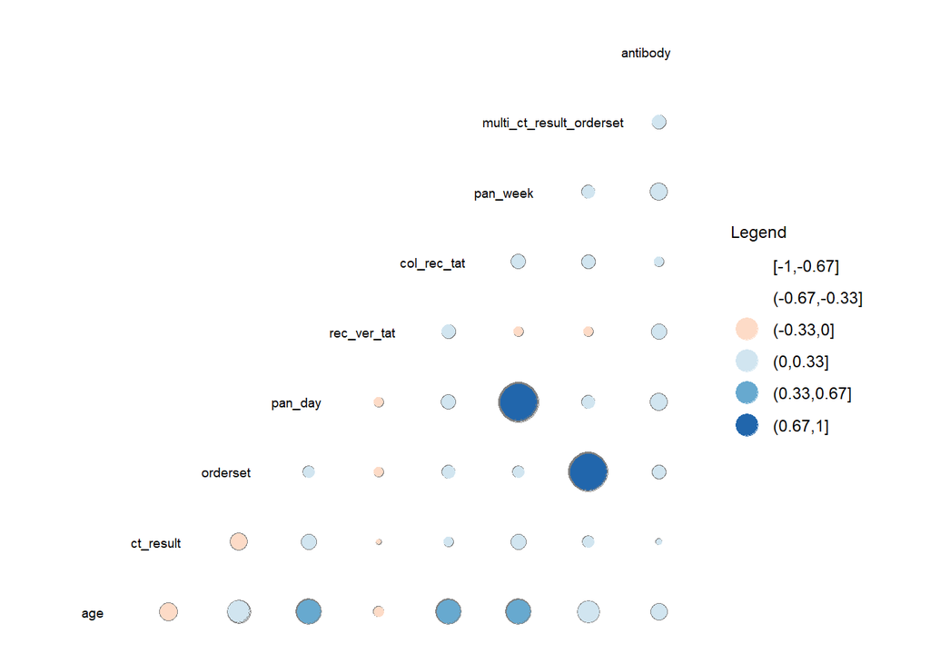

With a correlation matrix, we could observe some few correlations:  
- Strongest correlations *(0,67 - 1)* between `pan_day` & `pan_week` and `orderset` & `multi_ct_result_orderset`. Here, correlation is expected since `pan_week` and `multi_ct_result_orderset` were created out of `pan_day` and `orderset`  
- weaker correlations *(0,33 - 0,67)* between `age` & `pan_day`, `age` & `pan_week`, `age` & `col_rec_tat`. Again, `pan_week` is based on `pan_day` and is ignored  
- rest mostly correlations between *0 - 0,33* and some between *-0,33 - 0* and not significant

#### Pratik

#### Does the time spent waiting for the test result improve during these 100 days that the dataset includes?

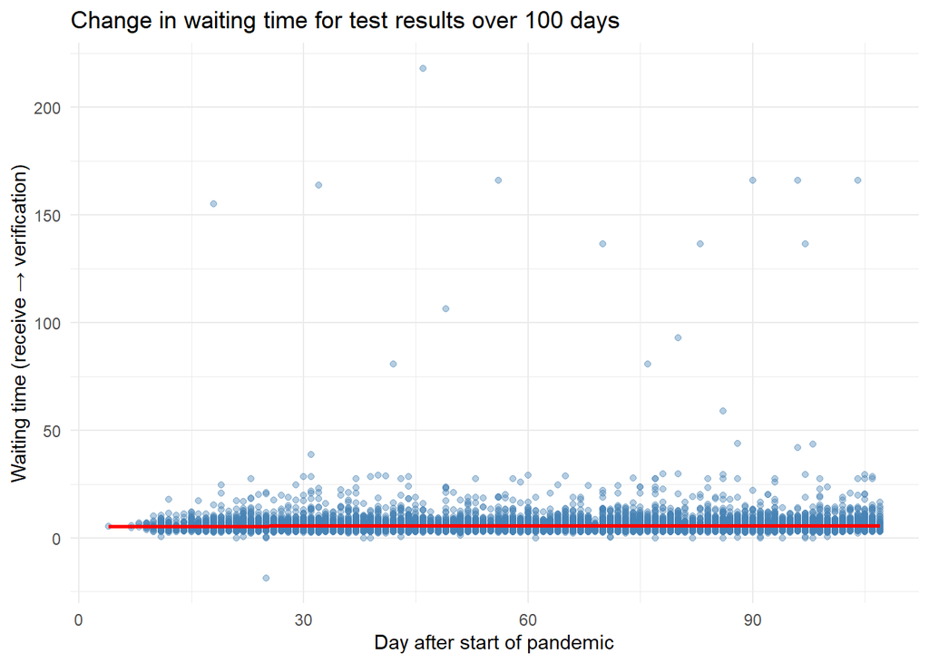

#### Were there more females than males that took the test at a drive through?

```
##         drive_thru_ind
## gender     No  Yes
##   female 3736 3997
##   male   3670 3912
```

Yes, there were more females *(n=3997)* than males *(n=3912)* to take test at a drive through. First, filter was done to select only cases with test done at a drive through and a table was generated to segregate by gender.

#### Fatemeh

#### Does the distribution of the `ct_result` differ with sex group?

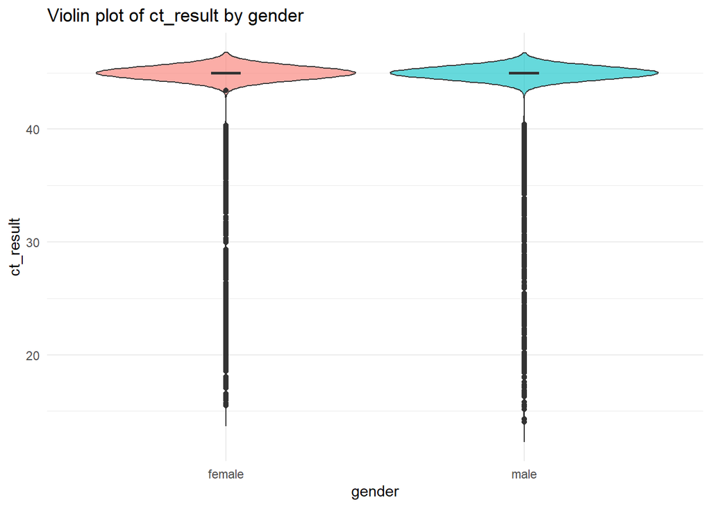

The violin plot indicates that the `ct_result` distributions for females and males are nearly identical, showing no meaningful difference between the two sex groups. Their medians and overall spread are very similar, with no distinct peaks. Therefore, `gender` has no meaningful effect on `ct_result`.

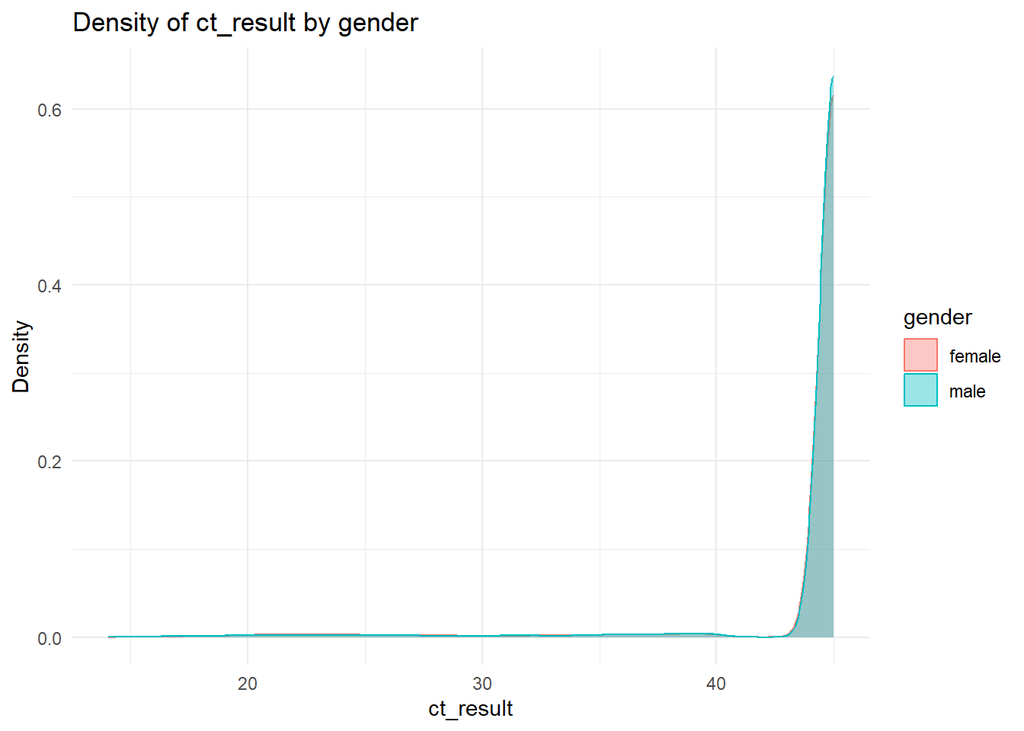

Next, we tried a density plot. This plot shows that the `ct_result` distributions for females and males almost completely overlap, showing no meaningful difference between the two sex groups.

#### Sebastian

#### Does the distribution of the `ct_result` differ with payor_group?

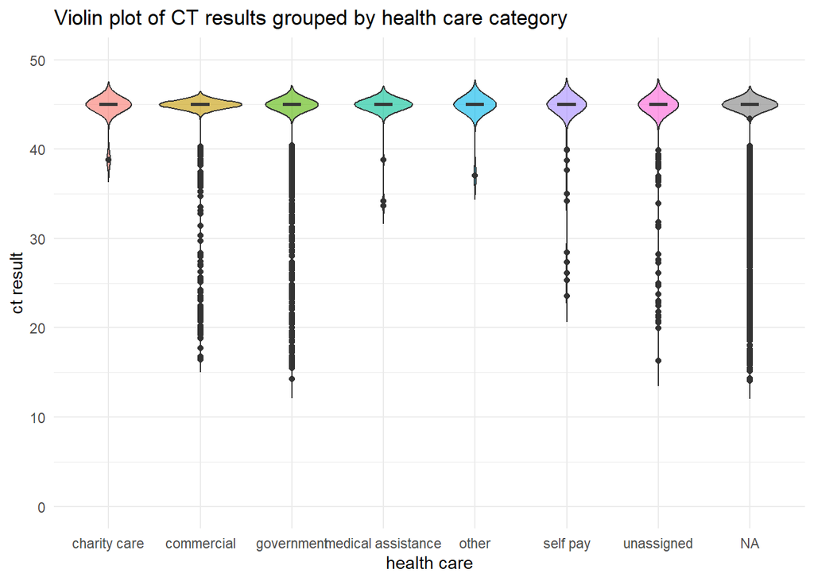

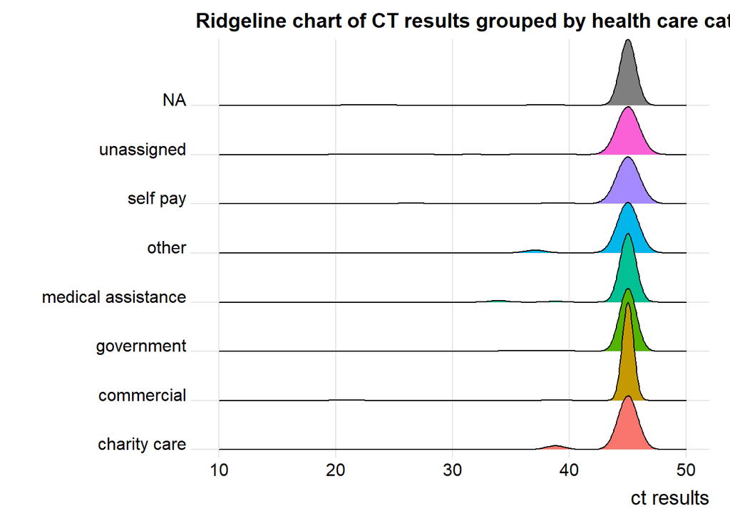

For this question we used first a violin plot for the distribution shape and additionally a Ridgeline chart to show the density distribution for all groups. All `payor_group` share the largest distribution at `ct_result` = *45*, with `commercial` having the most results at *45*. `Government` and `medical assistance` have second highest number at *45*. Rest of the groups have approx. the same number. Some outlier are obserable in all groups, with `commercial`, `government` and `NA` having the most. Least outliers are in groups `charity care` and `other`, `medical assistnance`.

### Task 5 - Analyse the dataset and answer the following questions:

#### Pratik

#### Are there more positive tests in the drive through?

```
##           drive_thru_ind
## result       No  Yes
##   invalid   137   92
##   negative 6888 7338
##   positive  381  479
```

```
##           drive_thru_ind
## result              No         Yes
##   invalid  0.008945478 0.006007183
##   negative 0.449755142 0.479138100
##   positive 0.024877571 0.031276526
```

When we see the outcome of the tests across the site of specimen collection, we find more positive tests in the drive-through group both by count *(479 versus 381)* and proportion *(3.1% versus 2.5%)*.

#### Fatemeh

#### Is there a difference in the distributions of `ct_results` between different outcome groups (result)?

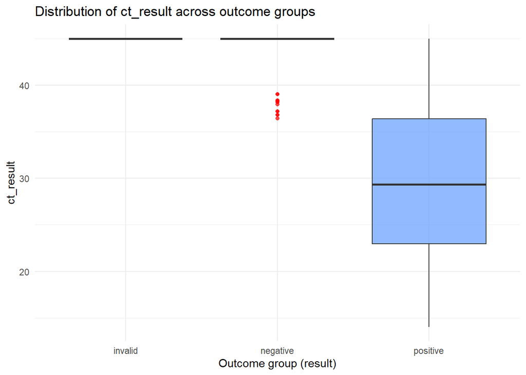

#### Sebastian

#### Is the age of the individual associated with whether the test result is negative or positive?

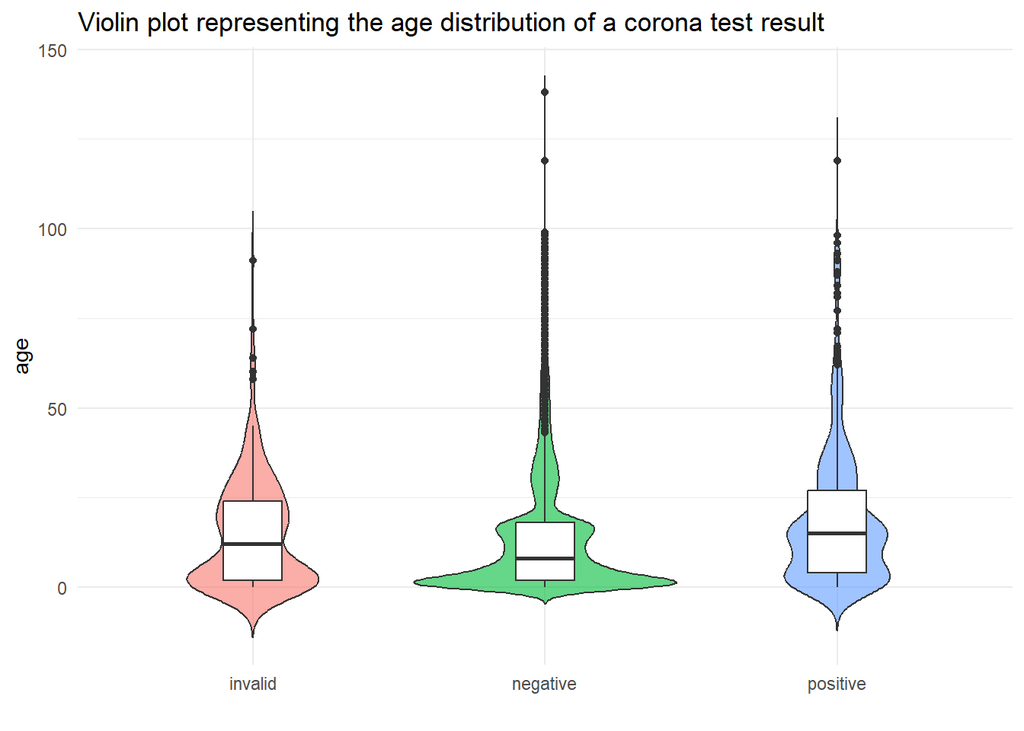

### Task 6 - Write a short report in an Rmd format.

We summarized our structure, data sets, procedures for every task and plots, including analysis in a RMarkdown protocol `exam_summary_data_freak.Rmd`. This file is located in the script/task6 folder and the .html output in the results folder.